# Constructing endogenous value function $R(\cdot, \rho, i, z)$ via lotteries

Source codes prepared by [T. Kam, H.S. Lee, S. Ng](https://i.pinimg.com/736x/60/00/c4/6000c446ade9ff211f45c51b96bc3109.jpg)

```python
import bcw_bj_Lemma_1 as bcw_bj
import numpy as np
import scipy as sp
from textwrap import dedent
from scipy.optimize import brentq, fsolve
import matplotlib.pyplot as plt
from mpl_toolkits import mplot3d
import sys
import time
import collections as collections
from cycler import cycler

from scipy.spatial import ConvexHull
import setops as setops # Custom module by TK, from CSM

import sympy as sym
from IPython.display import display, Math
```

```python
# Instantiate class as MODEL object, at current calibrated params
self = bcw_bj.baseline_mod(σ_DM=0.28, c=1.0)

# Set (partial) equilibrium i to calibrated SME solution
i = 0.021692264956258474
```

## New functions added

```python
def z_cutoffs(self, i):
    """Define the four cutoff levels for z as in Lemmata 1-3:
    0 < z_tilde_i < zhat < z_prime < ∞."""

    z_hat = (self.c/(1-self.σ_DM))**((self.σ_DM-1)/self.σ_DM)
    z_prime = z_hat*(1/(1-self.σ_DM))**(-(self.σ_DM-1)/self.σ_DM)
    z_tilde = z_hat*(1+i)**(-1/self.σ_DM)
    # z_breve = (1-self.c) + z_hat*self.σ_DM
    # z_breve =((1+self.σ_DM*z_tilde)/self.c)**(1-self.σ_DM)

    # Sanity check!
    # zcut = np.diff([z_tilde, z_hat])
    if z_tilde <= z_hat:
        print("🥳 Congrats: Your cutoffs are in order!")
        z_cutoffs_str = '\\tilde{z}_{i} < \\hat{z} < z^{\\prime}'
        display(
            Math(z_cutoffs_str)
            )
        z_cutoffs = [z_tilde, z_hat, z_prime]
        print(['%.3f' % x for x in z_cutoffs])
    else:
        print("💩 You have a problem with your cutoff ordering!")

    return z_tilde, z_hat, z_prime
```

```python
def R(self, p_grid, Rex, DropFakes=True):
    """Find convex hull of graph(Rex) to get R - See Appendix B.3
    Taken from https://github.com/phantomachine/csm/
    """
    Rex_graph = np.column_stack((p_grid, Rex))

    # Step 0:   Find Convex hull of { ρ, Rex(ρ) }
    mpoint = np.array([p_grid.max(), Rex.min()])  # SE corner
    graph = np.vstack((Rex_graph, mpoint))
    chull = ConvexHull(graph)
    extreme_pts = graph[chull.vertices, :]

    # Step 1: Intersection between original function Rex and ext. pts.
    v_intersect_graph, ind = setops.intersect(Rex_graph, extreme_pts)[0:2]

    # Step 2: First difference the index locations
    idiff = np.diff(ind, n=1, axis=0)

    # Step 3: if idiff contains elements > 1 then we know exist one/more line
    # segment (i.e., more than one set of lotteries played). Location where
    # straddles more than 1 step
    idz = np.where(idiff > 1)[0]

    # Step 4: Given the jumps, we have the end points defining each lottery!
    idz = np.column_stack((idz, idz+1))

    # Step 5: Store lottery supports
    lottery_supports = v_intersect_graph[idz, 0]
    lottery_payoffs = v_intersect_graph[idz, 1]

    # print(lottery_supports)
    # Step 6: Interpolate to approximate R
    R_fit = self.InterpFun1d(v_intersect_graph[:, 0],
                            v_intersect_graph[:, 1])

    # Step 7: Eliminate Fake Lotteries (below-tolerance numerical imprecisions)
    if DropFakes:
        selector = []
        for idx_lot in range(lottery_supports.shape[0]):
            # Lottery prizes for at current lottery segment, idx_lot
            p_lo, p_hi = lottery_supports[idx_lot, :]
            # Conditions: points between current lottery segment
            find_condition = (p_grid > p_lo) & (p_grid < p_hi)
            # Value of Vtilde between current lottery segment
            Rex_p_temp = Rex[find_condition]
            # Value of V between current lottery segment
            R_p_temp = R_fit(p_grid[find_condition])
            # Check: Is R "significantly different" from Rex at lottery segment?
            gap = np.absolute(R_p_temp - Rex_p_temp).max()
            if gap > 1e-8:
                selector.append(idx_lot)  # Keep, if "YES"
        # Update definition of the set of lotteries
        lottery_supports_temp = lottery_supports[selector, :]
        lottery_payoffs_temp = lottery_payoffs[selector, :]
        # if lottery_supports_temp.size == 0:
        #     lottery_supports = lottery_supports[0, :]
        #     lottery_payoffs = lottery_payoffs[0, :]
        # else:
        if lottery_supports_temp.size > 0:
            lottery_supports = lottery_supports_temp
            lottery_payoffs = lottery_payoffs_temp
    # print(lottery_supports)
    # Step 8: Store R as evaluated on finite set p_grid
    R_grid = R_fit(p_grid)
    return R_grid, R_fit, lottery_supports, lottery_payoffs
```

```python
def plotRfun(self, i, z, ρ_range):

        ρ_hat = self.ρ_hat_func(z)
        ρ_tilde = self.ρ_tilde_func(z, i)
        ρ_m0 = self.c/(1-self.σ_DM)
        # ρ_range = np.linspace(self.c, 1.5, 1000)

        fig, ax = plt.subplots()
        # Graph - profit from credit buyers
        plt.plot(ρ_range, self.G1(ρ_range, i, z),
                label=r"$G_{1}$", color="b", linestyle='dotted')
        # Graph - profit from money constrained
        plt.plot(ρ_range, self.G2(ρ_range, i, z),
                label=r"$G_{2}$", color="orange", linestyle="--")
        # Graph - profit from money unconstrained
        plt.plot(ρ_range, self.G3(ρ_range, i, z),
                label=r"$G_{3}$", color="green", linestyle='dashdot')
        # Ex-post profit (R^{ex})
        Rex = self.R_ex(ρ_range, i, z)
        plt.plot(ρ_range, Rex,
                label=r"$R^{ex}$",
                color="r",
                linewidth=2.5,
                alpha=0.7,)

        # Effective (ex-ante) but post-match lottery value/profit, R
        R_grid = R(self, ρ_range, Rex, DropFakes=True)[0]
        plt.plot(ρ_range, R_grid, '-k', label=r"$R$", alpha=0.9,)

        # Add tick-marks for pricing cutoffs and Ramsey monopoly price
        ax.set_xticks(ticks=[self.c, ρ_hat, ρ_tilde, ρ_m0],
                                labels=[r"$c$",
                                        r"$\hat{\rho}$",
                                        r"$\tilde{\rho}_{i}$",
                                        r"$\rho^{m}_{0}$"]
                        )

        plt.legend()
        plt.show()

        return plt, fig, ax, ρ_hat, ρ_tilde, ρ_m0
```

```python
# def i_bar(self):
#     """Upper-bound for i for Case 2b to arise."""
#     σ = self.σ_DM
#     ibar = (σ*(1/(1-σ))**(1-1/σ) + self.c**(-(1-1/σ)))**(-σ*(1-σ)) - 1
#     return ibar
```

```python
# # Check that ibar is positive
# ibar = i_bar(self)
# print(ibar)
# if ibar <= 0:
#     print("WARNING: ibar is not strictly positive!")
# else:
#     print("ibar is positive")
```

## The cut-offs

Assume that $\sigma\in(0,1)$ and $c\in(0,1]$ such that:

$$0<\left(\frac{c}{1-\sigma}\right)^{1-\frac{1}{\sigma}}=:\hat{z},$$

- There exists a $\tilde{z}_{i}:=(1+i)^{-\frac{1}{\sigma}}\hat{z}<\hat{z}$.

```python
# Get cut-off values and check ordering is correct!
z_tilde, z_hat, z_prime = z_cutoffs(self, i)
```

```
🥳 Congrats: Your cutoffs are in order!
```

$\displaystyle \tilde{z}_{i} < \hat{z} < z^{\prime}$

```
['0.398', '0.430', '1.000']
```

## Case 2b is non-analytical

- We can show a lower bound on $1+i$ that can be satisfied for any value of $\sigma\in(0,1)$ and $c\in(0,1]$.
- If this lower bound is satisfied, this implies that there is a bounded range $I_{i}:=[\breve{z}_{i}, \tilde{z}_{i}]$ of non-negative measure ($\breve{z}_{i} \leq \tilde{z}_{i}$) such that $G_{2}(\hat{\rho};z) \geq G_{1}(\rho^{m}_{0}; i)$.
  - $G_{2}(\hat{\rho};z) = G_{1}(\rho^{m}_{0}; i)$ iff $| I_{i} | = 0$ or $\breve{z}_{i} = \tilde{z}_{i}$
  - $G_{2}(\hat{\rho};z) > G_{1}(\rho^{m}_{0}; i)$ iff $| I_{i} | > 0$ or $\breve{z}_{i} < \tilde{z}_{i}$

```python
# Case 2b
def LHS(self, z):
    return z - self.c*z**(1/(1-self.σ_DM))

def RHS(self, i):
    z_tilde = z_cutoffs(self, i)[0]
    return self.σ_DM*z_tilde/self.c
```

```
🥳 Congrats: Your cutoffs are in order!
```

$\displaystyle \tilde{z}_{i} < \hat{z} < z^{\prime}$

```
['0.398', '0.430', '1.000']
```

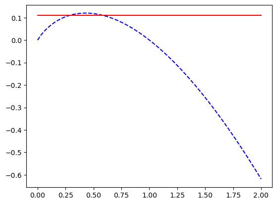

```python
zgrid = np.linspace(0.0001, 2.0, 1000)
lhs = LHS(self, zgrid)
rhs = RHS(self, i)
plt.figure()
plt.plot(zgrid, lhs, '--b', zgrid, rhs*np.ones(zgrid.shape), '-r')
plt.show()
```

```python
def i_check(self, i, zstar_lhs):
    """Sufficient condition on i for Case 2b to have a non-degenerate solution
    for \breve{z}_{i}. zstar_lhs is the maximum value of the hump-shaped
    polynomial function on the LHS of the inequality derived in Case 2b."""
    σ = self.σ_DM
    c = self.c
    zhat = z_cutoffs(self, i_test)[1]
    # lhs = 1 + i
    # rhs = (zhat**σ) * ( (1-σ)/σ)*(1 - c*((1-σ)/c)**(σ/(1-σ)) )**(-σ)
    lhs = LHS(self, zstar_lhs)
    rhs = zhat*(σ/c)*(1+i)**(-1/σ)
    print("\n\t LHS(zstar_lhs) = %5.6f" % (lhs))
    print("\t RHS(i) = %5.6f" % (rhs))
    if lhs >= rhs:
        print("\nLHS >= RHS: Case 2b exists")
        print("\t\t\t" + r"$\breve{z}_{i} < \tilde{z}_{i}$")
    else:
        print("Not well-defined ... Case 2b")
```

```python
# Case 2b does not seem to arise for too low i

# Here's an example with i_test high enough, then Case 2b exists
i_test = i*7
zstar_lhs = (1-self.σ_DM)/self.c
i_check(self, i_test, zstar_lhs)
```

```
🥳 Congrats: Your cutoffs are in order!
```

$\displaystyle \tilde{z}_{i} < \hat{z} < z^{\prime}$

```
['0.259', '0.430', '1.000']

	 LHS(zstar_lhs) = 0.086348
	 RHS(i) = 0.072616

LHS >= RHS: Case 2b exists
			$\breve{z}_{i} < \tilde{z}_{i}$
```

### Takeaway lesson from Case 2b numerical testing ...

The condition for Case 2b---i.e., when $G_{2}(\hat{\rho};z) \geq G_{1}(\rho^{m}_{0}; i)$---to exist depends on $i$ relative to a given $z$.

This condition can be re-written as

$$ \underbrace{ z - c z^{\frac{1}{1-\sigma}} }_{LHS(z)} \geq \underbrace{ (1+i)^{-1/\sigma} (\sigma/c)\hat{z} }_{RHS(i)}. $$

    Since $z_{1} > \hat{z}$ (i.e., exceeds the real balance consistent with firms serving money-constrained agents) then $z_{1}$ cannot be an equilibrium cutoff candidate for $\breve{z}_{i}$. Thus $\breve{z}_{i}$ must be the smaller of the possible two roots solving $LHS(z) = RHS(i)$.

Now, depending on $z$ and $i$, it may be that:

1. $\breve{z}_{i} < \tilde{z}_{i}$, or
2. $\breve{z}_{i} \geq \tilde{z}_{i}$.

So the natural lower bound for the (possibly degenerate) interval describing Case 2b is $\mathring{z}_{i} = \min\{\breve{z}_{i} ,\tilde{z}_{i}\}$.

## Case 1a

**NOTE**:

- The function `R` has many outputs.
- The second element in the output tuple from `R` is a `SciPy` interpolant object called `Rfit`.
- You can apply the object `Rfit` directly for function evaluation when defining distribution function $J_{i}$ later.

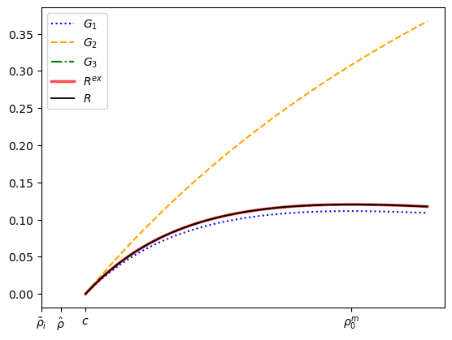

```python
ρ_range = np.linspace(self.c, 1.5, 1000)
weight = 1.1
z = weight*z_prime
plt, fig, ax, ρ_hat, ρ_tilde, ρ_m0 = plotRfun(self, i, z, ρ_range)
```

### Usage in SME - Notes for Sam/HS

Below is an example of `Rfit` for Case 1:

- Observe that all lotteries in this case are degenerate.
- So if you evaluate `Rfit` against `Rex` on the same grid points `ρ_range`, you should get exactly the same function evaluations.

```python
# Ex-post profit (R^{ex}) - Case 1
Rex = self.R_ex(ρ_range, i, z)

# Effective (ex-ante) but post-match lottery value/profit, R - Case 1
R_grid, R_fit, lottery_supports, lottery_payoffs = R(
    self, ρ_range, Rex, DropFakes=True)

# Note: R_fit(ρ_range) = R_grid since both are evaluated on the
#       same domain/grid as R_grid!
if (np.absolute(R_fit(ρ_range) - Rex)).max() > 1e-12:
    print("ERROR: The two functions are not the same!")
else:
    print("All good!")
```

```
All good!
```

As expected, the lottery set is empty:

```python
lottery_supports
```

```
array([], shape=(0, 2), dtype=float64)
```

```python
lottery_payoffs
```

```
array([], shape=(0, 2), dtype=float64)
```

## Case 1b

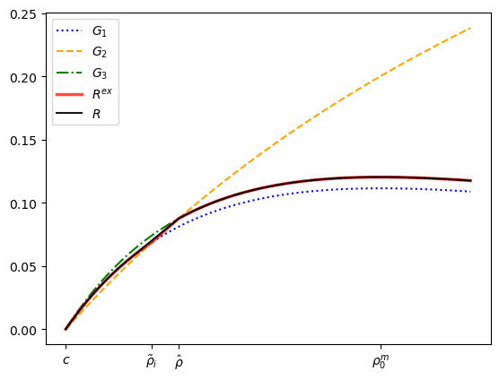

```python
ρ_range = np.linspace(self.c, 1.5, 1000)
weight = 0.5
z = weight*z_hat + (1-weight)*z_prime
plt, fig, ax, ρ_hat, ρ_tilde, ρ_m0 = plotRfun(self, i, z, ρ_range)
```

## Case 2a

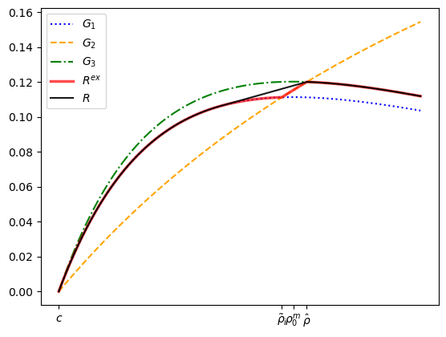

```python
ρ_range = np.linspace(self.c, 1.6, 1000)
weight = 0.55
z = weight*z_tilde + (1-weight)*z_hat
plt, fig, ax, ρ_hat, ρ_tilde, ρ_m0 = plotRfun(self, i, z, ρ_range)
```

## Case 2b

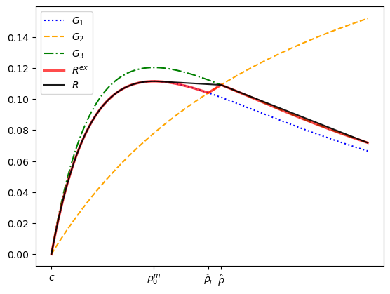

```python
ρ_range = np.linspace(self.c, 2.2, 2000)
weight = 0.3
z = (1-weight)*z_tilde
plt, fig, ax, ρ_hat, ρ_tilde, ρ_m0 = plotRfun(self, i, z, ρ_range)
```

### Usage in SME - Notes for Sam/HS

Below is an example of `Rfit` for Case 2b:

- There should be a lottery.
- So if you evaluate `Rfit` against `Rex` on the same grid points `ρ_range`, you should expect gaps!

```python
# Ex-post profit (R^{ex}) - Case 1
Rex = self.R_ex(ρ_range, i, z)

# Effective (ex-ante) but post-match lottery value/profit, R - Case 1
R_grid, R_fit, lottery_supports, lottery_payoffs = R(
    self, ρ_range, Rex, DropFakes=True)

# Note: R_fit(ρ_range) = R_grid since both are evaluated on the
#       same domain/grid as R_grid!
if (np.absolute(R_fit(ρ_range) - Rex)).max() > 1e-12:
    print("WARNING: The two functions are not the same!")
else:
    print("All good!")
```

```
WARNING: The two functions are not the same!
```

As expected, the lottery set is non-empty:

```python
# Values of R at outcomes/prizes of lottery
lottery_payoffs
```

```
array([[0.11133781, 0.10908753],
       [0.10908753, 0.07181962]])
```

```python
# Finite set: lottery support, possible outcomes (prizes) of lottery
lottery_supports
```

```
array([[1.4082041 , 1.64412206],
       [1.64412206, 2.2       ]])
```

```python
# Values of $\rho^{m}_{0}$ and $\hat{\rho}$
ρ_cuts = np.array([ρ_m0, ρ_hat])
ρ_cuts
```

```
array([1.38888889, 1.64381048])
```

The last interval `ρ_cuts` gives us the values, respectively, of $\rho^{m}_{0}$ and $\hat{\rho}$ for Case 2b.

## Case 3

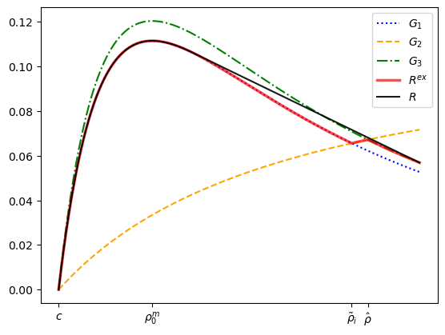

```python
ρ_range = np.linspace(self.c, 2.5, 1000)
weight = 0.7
z = (1-weight)*z_tilde
plt, fig, ax, ρ_hat, ρ_tilde, ρ_m0 = plotRfun(self, i, z, ρ_range)
```

## Logs

Completed:

- In this example notebook, I have modified HS/Sam's class file `bcw_bj_Lemma_1.py` by adding:
  - `InterpFun1d`
  - a vectorized version of ex-post profit function `R_ex` (previously called `R` by HS/Sam)
  - `z_cutoffs` (used directly above)
  - `R` (used directly above)